# Discrete Time Markov Model Analysis of Cognitive Decline

Examining the Association Between Procrastination and Cognitive Transitions

Author

Affiliations

[Cormac Monaghan](https://c-monaghan.github.io/)

Hamilton Institute, Maynooth University, Ireland

Department of Psychology, Maynooth University, Ireland

Abstract

This analysis examines transitions between cognitive states (Normal Cognition, MCI, Dementia) using discrete-time Markov models, with particular focus on procrastination as a risk factor.

## Setting up

### Loading packages

**Check out my packages**

```r
# Packages ---------------------------------------------------------------------
library(dplyr)
library(tidyr)
library(ggplot2)
library(patchwork)
```

### Loading functions

**Check out my functions**

```r
# Functions --------------------------------------------------------------------
extract_years <- function(data, years, impute = TRUE, cog_total = FALSE, absorbing = TRUE) {
  # Extracts cognitive function data for specified years from a dataset.
  # Converts numeric cognitive status codes (1, 2, 3) into descriptive labels
  # ("Normal Cognition", "MCI", "Dementia") for easier interpretation.
  # Arguments:
  #   - data: The input dataset containing cognitive function data.
  #   - years: A vector of years for which data should be extracted.
  # Returns:
  #   - A dataset with ID and cognitive status columns for the specified years.

  # Create dynamic column names based on the years provided
  cogfunction_cols <- paste0("cogfunction", years)
  cogtotal_cols    <- paste0("cogtot27_imp", years)

  if(cog_total == FALSE) {
    data <- data |>
      # Select only the ID column and cognitive function columns for the specified years
      select(ID, any_of(cogfunction_cols)) |>
      mutate(across(!c(ID), ~ case_when(
        .x == 1 ~ "Normal Cognition",
        .x == 2 ~ "MCI",
        .x == 3 ~ "Dementia",
        TRUE ~ NA_character_  # To handle missing/other cases
      )))
  } else {
    data <- data |>
      # Select only the ID column and cognitive function columns for the specified years
      select(ID, any_of(cogtotal_cols)) |>
      rename_with( .cols = !ID, .fn = ~ stringr::str_replace(
        string = .x,
        pattern = "cogtot27_imp",
        replacement = "cog_score_"))
  }

  if(impute == TRUE){
    data <- data |>
      tidyr::pivot_longer(
        cols = !ID,
        names_to = "Wave",
        values_to = "Status") |>
      group_by(ID) |>
      tidyr::fill(Status, .direction = "down") |>
      ungroup() |>
      tidyr::pivot_wider(names_from = "Wave", values_from = "Status")
  }

  if(absorbing == TRUE) {
    data <- data |>
      tidyr::pivot_longer(
        cols = !ID,
        names_to = "Wave",
        values_to = "Status") |>
      group_by(ID) |>
      mutate(Status = ifelse(cumany(Status == "Dementia"), "Dementia", Status)) |>
      ungroup() |>
      tidyr::pivot_wider(names_from = "Wave", values_from = "Status")
  }

  return(data)
}

pivot_and_factorise <- function(data) {
  # Converts cognitive function data from wide to long format and factorizes key variables.
  # Pivots multiple cogfunction columns into wave/status pairs and converts categorical
  # variables (Gender, Education, status) to factors with meaningful labels.
  # Arguments:
  #   - data: Dataset containing cognitive function variables in wide format
  # Returns:
  #   - Long-format dataset with factorized variables, ordered by ID and wave
  #
  data |>
    tidyr::pivot_longer(
      cols = starts_with("cogfunction"), names_to = "wave",
      names_prefix = "cogfunction", values_to = "status") |>
    mutate(
      Gender = factor(Gender, levels = c(0, 1)),
      Education_tri = factor(Education_tri, levels = c(0, 1, 2)),
      wave = factor(wave),
      status = factor(status,
                      levels = c("Normal Cognition", "MCI", "Dementia"),
                      labels = c(1, 2, 3))) |>
    relocate(wave, .after = ID) |>
    relocate(status, .after = wave)
}

create_transition_table <- function(year_to, year_from) {
  # Creates a transition frequency table between two specified years of cognitive status data.
  # Calculates row sums and total observations for transition analysis.
  # Arguments:
  #   - year_to: Target year for transitions (character or numeric)
  #   - year_from: Origin year for transitions (character or numeric)
  # Returns:
  #   - List containing:
  #     - transition frequency table
  #     - row sums
  #     - total observations
  #
  tbl <- table(
    table_data[[paste0("HRS_", year_to)]],
    table_data[[paste0("HRS_", year_from)]],
    dnn = c(year_to, year_from)
  )

  # Calculate row sums and total
  row_sums <- rowSums(tbl)
  total <- sum(row_sums)

  # Return as a list with both the table and summary stats
  list(
    table = tbl,
    row_sums = row_sums,
    total = total
  )
}

create_transition_dataset <- function(data, transition_results) {
  # Combines multiple transition tables into a single analysis-ready dataset.
  # Formats period labels, ensures consistent factor levels, and structures data for visualization.
  # Arguments:
  #   - data: List of year pairs to process (e.g., list(c(2016,2018)))
  #   - transition_results: List containing transition tables from create_transition_table()
  # Returns:
  #   - Tidy dataset with transition frequencies between all specified periods
  #
  data |>
    purrr::map_dfr(~ {
      period_name <- paste(.x[2], .x[1], sep = " - ")
      tbl <- transition_results[[paste(.x[2], .x[1], sep = "-")]]$table

      as.data.frame(tbl) |>
        rename(t_minus_1 = 1, t = 2) %>%  # Positional renaming
        mutate(Period = period_name, .before = t_minus_1)
    }) |>
    mutate(
      Period = stringr::str_replace(Period, "(\\d+) - (\\d+)", "\\2 - \\1"),
      Period = factor(Period, levels = c("2016 - 2018", "2018 - 2020", "2020 - 2022")),
      t_minus_1 = factor(t_minus_1, levels = c("Normal Cognition", "MCI", "Dementia")),
      t = factor(t, levels = c("Normal Cognition", "MCI", "Dementia"))
    )
}

create_transitions <- function(data, absorbing = FALSE){
  # Reshapes data from wide to long format to track cognitive status transitions over time.
  # Calculates the next wave's cognitive status for each individual and creates a transition column.
  # Optionally treats "Dementia" as an absorbing state, meaning once an individual is classified
  # with dementia, their status cannot change in subsequent waves.
  # Arguments:
  #   - data: The dataset containing cognitive status data.
  #   - absorbing: A logical flag indicating whether "Dementia" should be treated
  #   as an absorbing state.
  # Returns:
  #   - A dataset with transition information, including current and next wave statuses.

  # Reshape the data from wide to long format to track cognitive status over waves
  data <- data |>
    select(ID, starts_with("cogfunction")) |>
    tidyr::pivot_longer(cols = !ID,
                        names_to = "Wave",
                        values_to = "Status") |>
    mutate(Wave = as.factor(stringr::str_replace(Wave, "cogfunction", ""))) |>
    # Arrange by ID and Wave to prepare for transition calculation
    arrange(ID, Wave) |>
    group_by(ID) |>
    # Get the next wave's cognitive status for each person
    mutate(next_wave_status = lead(Status)) |>
    ungroup()
```

```r
  # We can optionally specify dementia as an absorbing state
  # Once an individual is classified with dementia they cannot be classified
  # with anything else
  if(absorbing == TRUE) {
    data <- data |>
      group_by(ID) |>
      mutate(
        Status = ifelse(cumany(Status == "Dementia"), "Dementia", Status),
        next_wave_status = ifelse(cumany(Status == "Dementia"), "Dementia", next_wave_status),
        transition = paste(Status, next_wave_status, sep = " to ")
      ) |>
      filter(Wave %in% c(2016, 2018, 2020))
  }

  # Filter out rows where either the current or next status is missing
  data <- data |>
    group_by(ID) |>
    filter(!is.na(Status), !is.na(next_wave_status)) |>
    ungroup() |>
    # Create a new column representing the transition from one status to the next
    mutate(
      transition = paste(Status, next_wave_status, sep = " to "),
      transition = factor(
        transition,
        levels = c("Normal Cognition to Normal Cognition", "Normal Cognition to MCI",
                   "Normal Cognition to Dementia", "MCI to Normal Cognition", "MCI to MCI",
                   "MCI to Dementia", "Dementia to Dementia")
      ))

  return(data)
}

observed_transition_matrix <- function(data) {
  # Converts transition data into a properly formatted probability transition matrix.
  # Ensures consistent state ordering and converts proportions to matrix format suitable
  # for multi-state modeling and visualization.
  # Arguments:
  #   - data: Transition dataset from create_transitions()
  # Returns:
  #   - Square transition probability matrix with states as row/column names
  #
  # The order I want my matrix in
  state_order <- c("Normal Cognition", "MCI", "Dementia")

  data |>
    group_by(Status, next_wave_status) |>
    summarise(freq = n(),  .groups = "drop") |>
    group_by(Status) |>
    mutate(freq = round(proportions(freq), 3)) |>
    ungroup() |>
    complete(Status, next_wave_status, fill = list(freq = 0)) |>
    tidyr::pivot_wider(names_from = next_wave_status, values_from = freq, names_sort = TRUE) |>
    tibble::column_to_rownames("Status") |>
    select(all_of(state_order)) |>
    _[state_order, ] |>
    as.matrix()
}

normalise <- function(x) {
  # Normalizes a matrix so that each row sums to 1.
  # Arguments:
  #   - x: The input matrix to normalize.
  # Returns:
  #   - A normalized matrix where each row sums to 1.
  x / rowSums(x)
}

tran_stack_graph <- function(data) {
  # Creates stacked bar charts visualizing cognitive state transitions across time periods.
  # Shows composition of current states by previous state, faceted by observation period.
  # Arguments:
  #   - data: Transition dataset from create_transition_dataset()
  # Returns:
  #   - ggplot object showing stacked transition proportions
  #
  data |>
    ggplot(aes(x = t_minus_1, y = Freq, fill = t)) +
    geom_col(position = "stack", colour = "black") +
    facet_wrap(~ Period, ncol = 3) +
    labs(
      x = "Previous State (t-1)",
      y = "Count",
      title = "Outcomes by Prior Cognitive State",
      fill = "Current State (t)"
    ) +
    ggokabeito::scale_fill_okabe_ito() +
    ggeasy::easy_move_legend("bottom")
}

tran_heat_map <- function(data) {
  # Generates heatmap visualization of transition frequencies between cognitive states.
  # Uses color intensity and labeled values to show transition patterns across time periods.
  # Arguments:
  #   - data: Transition dataset from create_transition_dataset()
  # Returns:
  #   - ggplot heatmap with state transitions as cells
  #
  data |>
    ggplot(aes(x = t_minus_1, y = t, fill = Freq)) +
    geom_tile(color = "white") +
    geom_text(aes(label = Freq), color = "black", size = 3.5) +  # Add counts
    scale_fill_gradient(low = "white", high = "steelblue") +
    facet_wrap(~ Period, ncol = 3) +  # Split by time period
    labs(
      x = "Previous State (t-1)",
      y = "Current State (t)",
      title = "Cognitive State Transitions Between Time Periods",
      fill = "Frequency"
    ) +
    theme(axis.text.x = element_text(angle = 45, hjust = 1)) +
    ggeasy::easy_move_legend("bottom")
}

tidy_predictions <- function(predictions) {
  # Restructures model prediction matrices into tidy format for visualization.
  # Converts numeric codes to factor labels and reshapes multiple prediction columns
  # into key-value pairs suitable for ggplot.
  # Arguments:
  #   - predictions: Raw prediction matrix from model output
  # Returns:
  #   - Long-format dataset with probabilities for each cognitive state
  #
  predictions |>
    as.matrix() |>
    as_tibble() |>
    mutate(
      Gender = factor(ifelse(Gender == 0, "Male", "Female"), levels = c("Male", "Female")),
      status_prev = case_when(
        status_prev == 1 ~ "Normal Cognition",
        status_prev == 2 ~ "MCI",
        status_prev == 3 ~ "Dementia",
      ),
      status_prev = factor(status_prev, levels = c("Normal Cognition", "MCI", "Dementia")),
      Total_p = as.numeric(Total_p),
      across(c(pred.1:pred.3), as.numeric)) |>
    tidyr::pivot_longer(cols = c(pred.1:pred.3), names_to = "status", values_to = "prob") |>
    mutate(status = case_when(
      status == "pred.1" ~ "Normal Cognition",
      status == "pred.2" ~ "MCI",
      status == "pred.3" ~ "Dementia"
    ),
    status = factor(status, levels = c("Normal Cognition", "MCI", "Dementia")),
    status_prev = factor(status_prev, levels = c("Normal Cognition", "MCI", "Dementia")))
}

plot_predictions_stationary <- function(predictions) {
  # Visualizes predicted transition probabilities from stationary multi-state models.
  # Shows probability curves by procrastination level, stratified by baseline state.
  # Arguments:
  #   - predictions: Tidy predictions from tidy_predictions()
  # Returns:
  #   - Faceted ggplot showing predicted probability curves
  #
  predictions |>
    ggplot(aes(x = Total_p, y = prob, colour = status_prev)) +
    geom_line(linewidth = 1) +
    ggokabeito::scale_colour_okabe_ito() +
    labs(
      title = "Predicted transition probabilities (stationary model)",
      # subtitle = "According to previous cognitive state",
      x = "Total Procrastination", y = "Probability", colour = "Previous State") +
    facet_wrap(~ status, labeller = labeller(
      status = function(x){paste0("Transition to: ", x)}
    ))
}
```

```r
get_time_varying_matrix <- function(model, time_point) {
  expand.grid(
    Gender = factor(0),
    Total_p = mean(data_stack$Total_p),
    status_prev = factor(1:3),
    wave = time_point) |>
    modelr::add_predictions(model, var = "prob", type = "probs") |>
    select(status_prev, starts_with("prob")) |>
    mutate(
      status_prev = factor(status_prev, labels = state_names),
      across(starts_with("prob"), ~round(., 3))) |>
    tibble::column_to_rownames("status_prev") |>
    as.matrix() |> `colnames<-`(state_names)
}
```

### Setting theme

**Check out my theme**

```r
colour <- "#212427"

theme_set(
  theme_minimal() +
    theme(
      plot.title = element_text(hjust = 0.5, size = 14, colour = colour, face = "bold"),
      plot.subtitle = element_text(hjust = 0.5, size = 12, colour = colour),
      axis.title = element_text(size = 10, colour = colour, face = "bold"),
      strip.text = element_text(size = 10, colour = colour, face = "bold"),
      legend.title = element_text(hjust = 0.5, colour = colour, face = "bold"),
      ))
```

### Reading in data

```r
data <- readxl::read_xlsx(here::here("data/data.xlsx"))
```

## 1 Research Questions and Hypotheses

### 1.1 Primary Hypothesis

In order to test this hypothesis we will be using a **discrete time Markov Model**

## 2 Data Preparation

Before preparing the data, we want to create a vector of covariates that we are interested in using in our analysis

```r
cols <- c("ID", "Gender", "Age", "Education_tri", "Cardio_risk_16", "Total_dep_2016", "Total_p")
```

```r
data_stack <- data |> extract_years(years = seq(2016, 2022, by = 2), impute = TRUE, absorbing = TRUE) |> na.omit()

head(data_stack)
```

```
# A tibble: 6 × 5
     ID cogfunction2016  cogfunction2018  cogfunction2020  cogfunction2022
  <dbl> <chr>            <chr>            <chr>            <chr>
1     1 Normal Cognition Normal Cognition Normal Cognition Normal Cognition
2     2 Normal Cognition Normal Cognition Normal Cognition Normal Cognition
3     3 Dementia         Dementia         Dementia         Dementia
4     4 Normal Cognition Normal Cognition Normal Cognition Normal Cognition
5     5 MCI              Normal Cognition Normal Cognition Normal Cognition
6     6 Normal Cognition Normal Cognition Normal Cognition Normal Cognition
```

### 2.1 Creating a stacked dataset

For each respondent we will now add in their relevant covariate data. Following this, we transform the data to long format and convert categorical variables to factors using the `pivot_and_factorise()` function. Additionally, we will fix the `Age` column to properly represent the age of the respondent at each time point

```r
data_stack <- data_stack |>
  inner_join(data[, cols], by = "ID") |>
  pivot_and_factorise() |>
  group_by(ID) |>
  mutate(Age = Age - (2022 - as.numeric(as.character(wave))))

head(data_stack)
```

```
# A tibble: 6 × 9
# Groups:   ID [2]
     ID wave  status Gender   Age Education_tri Cardio_risk_16 Total_dep_2016
  <dbl> <fct> <fct>  <fct>  <dbl> <fct>                  <dbl>          <dbl>
1     1 2016  1      1         72 2                          0              0
2     1 2018  1      1         74 2                          0              0
3     1 2020  1      1         76 2                          0              0
4     1 2022  1      1         78 2                          0              0
5     2 2016  1      1         75 2                          1              2
6     2 2018  1      1         77 2                          1              2
# ℹ 1 more variable: Total_p <dbl>
```

Finally, we will create a new variable `status_prev` that notes the cognitive status of the respondent in the previous wave $(t - 1)$. This will be done by using the `lag` function from the `dplyr` package.

```r
data_stack <- data_stack |>
  mutate(status_prev = lag(status), .after = status) |>
  ungroup() |>
  filter(wave != 2016, !is.na(Total_p))

head(data_stack)
```

```
# A tibble: 6 × 10
     ID wave  status status_prev Gender   Age Education_tri Cardio_risk_16
  <dbl> <fct> <fct>  <fct>       <fct>  <dbl> <fct>                  <dbl>
1     1 2018  1      1           1         74 2                          0
2     1 2020  1      1           1         76 2                          0
3     1 2022  1      1           1         78 2                          0
4     2 2018  1      1           1         77 2                          1
5     2 2020  1      1           1         79 2                          1
6     2 2022  1      1           1         81 2                          1
# ℹ 2 more variables: Total_dep_2016 <dbl>, Total_p <dbl>
```

## 3 Transition frequencies

We will now calculate the transition frequencies between cognitive states for each time period. We will use the `create_transition_table()` function to create a transition table for each time period. This will be done with the help of the `map()` function from the `purrr` package. Finally, to combine all the transition tables into one dataset, we will use the `create_transition_dataset()` function.

```r
# Creating a table dataset
table_data <- data |>
  extract_years(seq(2016, 2022, by = 2)) |>
  rename_with(~ gsub("cogfunction", "HRS_", .)) |>
  mutate(
    across(c(HRS_2016:HRS_2022), ~ factor(.x, levels = c("Normal Cognition", "MCI", "Dementia")))
  )

# Creating transition frequencies ---------------------------------------------
## These are the time periods we are interested in
time_periods <- list(
  c("2016", "2018"),
  c("2018", "2020"),
  c("2020", "2022")
)

# Applying function
transition_results <- purrr::map(time_periods, ~ create_transition_table(.x[1], .x[2]))
names(transition_results) <- purrr::map_chr(time_periods, ~ paste(.x[2], .x[1], sep = "-"))

### Creating one dataset
transition_frequencies <- time_periods |>
  create_transition_dataset(transition_results = transition_results)

head(transition_frequencies)
```

```
       Period        t_minus_1                t Freq
1 2016 - 2018 Normal Cognition Normal Cognition  713
2 2016 - 2018              MCI Normal Cognition   76
3 2016 - 2018         Dementia Normal Cognition    0
4 2016 - 2018 Normal Cognition              MCI   58
5 2016 - 2018              MCI              MCI   49
6 2016 - 2018         Dementia              MCI    0
```

### 3.1 Observed transition matrix

The probability distribution of transitions from one state to another can be represented into a transition matrix $P = (p_{ij})_{i,j}$ where each element of position $(i, j)$ represents the transition probability $p_{ij}$.

In order to create this matrix we will use both the `create_transitions()` and `observed_transition_matrix()` functions.

```r
## Creating observed transition matrix -----------------------------------------
transition_matrix_observed <- data |>
  extract_years(seq(2016, 2022, by = 2)) |>
  create_transitions() |>
  observed_transition_matrix()

transition_matrix_observed
```

```
                 Normal Cognition   MCI Dementia
Normal Cognition            0.895 0.096    0.009
MCI                         0.530 0.376    0.094
Dementia                    0.000 0.000    1.000
```

### 3.2 Visualisation

Let’s visualize both the transition frequencies (Figure 1) and matrix (Figure 2).

**Check out my code**

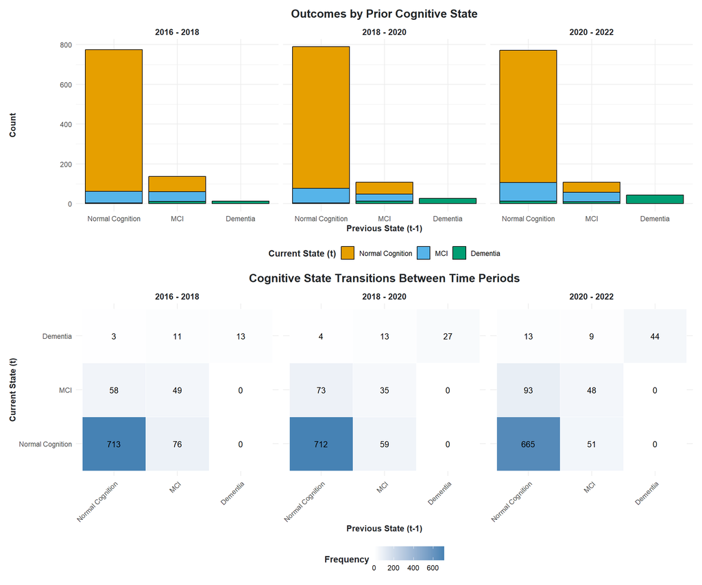

Figure 1: Transition frequencies between cognitive states for each time period.

```r
fig_1 <- transition_frequencies |> tran_stack_graph()
fig_2 <- transition_frequencies |> tran_heat_map()

fig_1 / fig_2
```

**Check out my code**

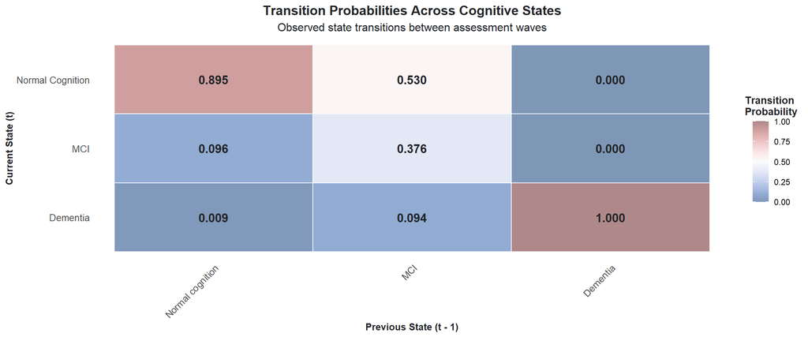

Figure 2: Observed transition matrix between cognitive states for the years 2016 - 2022.

```r
tran_df <- transition_matrix_observed |>
  as.data.frame() |>
  mutate(
    from_state = factor(c("Normal cognition", "MCI", "Dementia"),
                        levels = c("Normal cognition", "MCI", "Dementia"))
    ) |>
  reshape2::melt(
    id.vars = "from_state", variable.name = "to_state", value.name = "probability") |>
  mutate(
    to_state = factor(to_state, levels = rev(levels(to_state)))
    )

fig_2 <- tran_df |>
  ggplot(aes(x = from_state, y = to_state, fill = probability)) +
  geom_tile(color = "white", linewidth = 0.5) +
  geom_text(
    aes(label = format(round(probability, 3), nsmall = 3)),
    size = 4.5,
    color = "#212427",
    fontface = "bold") +
  colorspace::scale_fill_continuous_diverging(
    palette = "Blue-Red 3", mid = 0.50, alpha = 0.5,
    limits = c(0, 1), name = "Transition \nProbability") +
  labs(title = "Transition Probabilities Across Cognitive States",
       subtitle = "Observed state transitions between assessment waves",
       x = "Previous State (t - 1)",
       y = "Current State (t)") +
  theme(
    axis.text = element_text(size = 10),
    axis.text.x = element_text(angle = 45, hjust = 1, vjust = 1),
    legend.position = "right",
    legend.text = element_text(size = 9),
    panel.grid = element_blank()
  )

fig_2
```

## 4 Modelling

### 4.1 Markov Process Fundamentals

Discrete-time Markov models belong to a class of stochastic processes that satisfy the **Markov property**, which can be formally expressed as:

$$P(X_{t+1} = j \vert X_t = i, X_{t-1} = i_{t-1}, \dots X_0 = i_0) = P(X_{t+1} = j \vert X_t = i)
\tag{1}$$

This property establishes that the future state $X_{t+1}$ depends only on the current state $X_t$, not on the entire history of states.

#### 4.1.1 Transition Probability Matrix

For our three-state system (Normal Cognition, Mild Cognitive Impairment [MCI], Dementia), the transition matrix $P$ captures all possible transition probabilities:

$$P = \begin{bmatrix}
p_{11} & p_{12} & p_{13} \\
p_{21} & p_{22} & p_{23} \\
p_{31} & p_{32} & p_{33} \\
\end{bmatrix}
\tag{2}$$

where:

- $p_{ij} = P(X_{t+1} = j \vert X_t = i)$ represents the probability of transitioning from state $i$ to state $j$.
- Each row sums to 1, $\sum^3_{j=1} p_{ij} = 1 \quad \forall_i \in \{1, 2, 3\}$

#### 4.1.2 Multinomial Logistic Regression Formulation

We model the transition probabilities using **multinomial logistic regression**, where the log-odds of each transition relative to a reference state are linear functions of covariates.

For a system with $K$ states (using state $K$ as reference), we have:

$$log \left( \frac{P(Y = j \vert x)}{P(Y = k \vert x)} \right) = \beta_{j0} + \beta_j^Tx \qquad \text{for } j = 1, \dots K-1
\tag{3}$$

For non-reference states $j = 1, \dots, K - 1$

$$P(Y = j \vert x) = \frac{e^{\beta_{0j} + \beta_j^Tx}}{1 + \sum^{k - 1}_{k = 1} e^{\beta_{0k} + \beta_k^Tx}}
\tag{4}$$

For the reference state $K$:

$$P(Y = k \vert x) = \frac{1}{1 + \sum^{k - 1}_{k = 1} e^{\beta_{0k} + \beta_j^Tx }}
\tag{5}$$

#### 4.1.3 Time-Homogeneous Approach

Our implementation assumes time-homogeneous transitions, but the framework can be extended to time-varying probabilities:

$$P^{(t)} = \begin{bmatrix}
p_{11}^{(t)} & p_{12}^{(t)} & \cdots & p_{1n}^{(t)} \\
p_{21}^{(t)} & p_{22}^{(t)} & \cdots & p_{2n}^{(t)} \\
\vdots & \vdots & \ddots & \vdots \\
p_{n1}^{(t)} & \cdots & \cdots & p_{nn}^{(t)} \\
\end{bmatrix}
\tag{6}$$

Our primary analysis assumes the transition matrix remains fixed:

$$P^{(t)} \equiv P \qquad \forall \; t
\tag{7}$$

#### 4.1.4 Absorbing State Specification

We model Dementia as an absorbing state:

$$p_{3j} = \begin{cases}
1 \qquad \text{if } j = 3 \\
0 \qquad \text{otherwise} \end{cases}
\tag{8}$$

yielding the constrained transition matrix:

$$P = \begin{bmatrix}
p_{11} & p_{12} & p_{13} \\
p_{21} & p_{22} & p_{23} \\
0 & 0 & 1 \\
\end{bmatrix}
\tag{9}$$

### 4.2 Stationary model

We estimate three progressively complex stationary models using `nnet::multinom()`

**Check out my models**

```r
# Baseline model (only gender)
fit_1 <- nnet::multinom(
  status ~ Gender, family = multinomial,
  data = data_stack, trace = FALSE)

# With procrastination
fit_2 <- nnet::multinom(
  status ~ Gender + Total_p, family = multinomial,
  data = data_stack, trace = FALSE)

# Full model with previous state
fit_3 <- nnet::multinom(
  status ~ Gender + Total_p + status_prev, family = multinomial,
  data = data_stack, trace = FALSE)
```

#### 4.2.1 Model comparison

We evaluate model improvement using likelihood ratio tests:

$$D = -2 \times \ell_{\text{reduced}} - \ell_{\text{full}}
\tag{10}$$

```r
anova(fit_1, fit_2, fit_3) |>
  knitr::kable(caption = "Nested Model Comparison") |>
  kableExtra::kable_styling(
    bootstrap_options = c("striped", "hover"),
    full_width = FALSE)
```

Nested Model Comparison

| Model | Resid. df | Resid. Dev | Test | Df | LR stat. | Pr(Chi) |
| --- | --- | --- | --- | --- | --- | --- |
| Gender | 5510 | 3128.438 |  | NA | NA | NA |
| Gender + Total_p | 5508 | 3054.412 | 1 vs 2 | 2 | 74.02595 | 0 |
| Gender + Total_p + status_prev | 5504 | 2317.020 | 2 vs 3 | 4 | 737.39218 | 0 |

#### 4.2.2 Estimated parameters

**Check out my code**

```r
broom::tidy(fit_3) |>
  filter(term != "(Intercept)") |>
  mutate(
    y.level = case_when(
      y.level == "2" ~ "NC - MCI",
      y.level == "3" ~ "NC - Dementia"),
    term = case_when(
      term == "Gender1" ~ "Being female",
      term == "Total_p" ~ "Procrastination",
      term == "status_prev2" ~ "Previous state: MCI",
      term == "status_prev3" ~ "Previous state: Dementia",
      TRUE ~ term)
    ) |>
  mutate(across(c(estimate:p.value), ~ round(x = ., digits = 3)))
```

```
# A tibble: 8 × 6
  y.level       term                     estimate std.error   statistic p.value
  <chr>         <chr>                       <dbl>     <dbl>       <dbl>   <dbl>
1 NC - MCI      Being female                0.009     0.125       0.069   0.945
2 NC - MCI      Procrastination             0.023     0.005       4.59    0
3 NC - MCI      Previous state: MCI         1.77      0.136      13.0     0
4 NC - MCI      Previous state: Dementia    3.84      0     1122535.      0
5 NC - Dementia Being female               -0.132     0.294      -0.45    0.653
6 NC - Dementia Procrastination             0.018     0.012       1.56    0.12
7 NC - Dementia Previous state: MCI         2.82      0.299       9.43    0
8 NC - Dementia Previous state: Dementia   19.3       0     4639056.      0
```

#### 4.2.3 Model visualisation

Let’s visualize the predicted transition probabilities from the stationary models. We will show probability curves by procrastination level

**Check out my code**

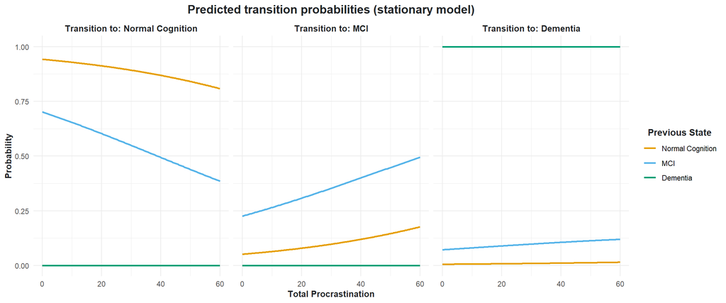

Figure 3: Predicted transition probabilities from the stationary model.

```r
## Making a prediction dataset -------------------------------------------------
pred_data <- expand.grid(
  Gender = factor(0),
  status_prev = levels(data_stack$status_prev),
  Total_p = seq(0, 60, length = 200))

## Plotting predictions
fig_3 <- pred_data |>
  modelr::add_predictions(model = fit_3, var = "pred", type = "probs") |>
  tidy_predictions() |>
  plot_predictions_stationary()

fig_3
```

#### 4.2.4 Estimated transition matrix

Finally, we can compare the observed and predicted transition matrices. We will use the estimated probabilities from the model to fill in the transition matrix.

```r
# Get all unique states
names <- c("Normal Cognition", "MCI", "Dementia")
states <- sort(unique(data_stack$status))
n_states <- length(states)

# Create empty transition matrix
transition_matrix_estimated <- matrix(
  0, nrow = n_states, ncol = n_states,
  dimnames = list(paste("From", names), paste("To", names))
  )

# Getting estimated probabilities
estimated_probs <- expand.grid(
  Gender = factor(0),
  Total_p = mean(data_stack$Total_p),
  status_prev = states) |>
  modelr::add_predictions(model = fit_3, var = "pred", type = "probs")

# Filling in matrix
for(i in 1:n_states) {
  transition_matrix_estimated[i, ] <- estimated_probs$pred[i, ]
}

transition_matrix_estimated |> round(digits = 3)
```

```
                      To Normal Cognition To MCI To Dementia
From Normal Cognition               0.896  0.095       0.009
From MCI                            0.556  0.347       0.097
From Dementia                       0.000  0.000       1.000
```

Let’s plot this and then compare with our observed matrix

**Check out my code**

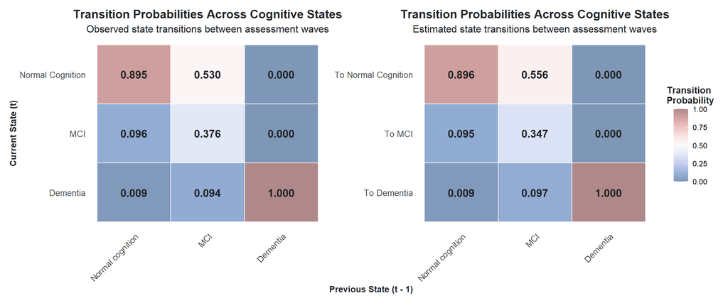

Figure 4: Comparison of observed and estimated transition matrices.

```r
tran_df_estimate <- transition_matrix_estimated |>
  as.data.frame() |>
  mutate(from_state = factor(
    c("Normal cognition", "MCI", "Dementia"),
    levels = c("Normal cognition", "MCI", "Dementia")
  )) |>
  reshape2::melt(id.vars = "from_state",
                 variable.name = "to_state",
                 value.name = "probability") |>
  mutate(to_state = factor(to_state, levels = rev(levels(to_state))))

fig_4 <- tran_df_estimate |>
  ggplot(aes(x = from_state, y = to_state, fill = probability)) +
  geom_tile(color = "white", linewidth = 0.5) +
  geom_text(
    aes(label = format(round(probability, 3), nsmall = 3)),
    size = 4.5,
    color = "#212427",
    fontface = "bold") +
  colorspace::scale_fill_continuous_diverging(
    palette = "Blue-Red 3", mid = 0.50, alpha = 0.5,
    limits = c(0, 1), name = "Transition \nProbability") +
  labs(title = "Transition Probabilities Across Cognitive States",
       subtitle = "Estimated state transitions between assessment waves",
       x = "Previous State (t - 1)",
       y = "Current State (t)") +
  theme(
    axis.text = element_text(size = 10),
    axis.text.x = element_text(angle = 45, hjust = 1, vjust = 1),
    legend.position = "right",
    legend.text = element_text(size = 9),
    panel.grid = element_blank()
  )

fig_2 + fig_4 + plot_layout(axis_titles = "collect", guides = "collect")
```

### 4.3 Non-stationary model

We can also estimate a non-stationary model (Equation 6) by incorporating time `(wave)` into our model. This model allows for time-varying transition probabilities $p^{(t)}_{ij}$.

We estimate three progressively complex non-stationary models:

- Additive time effects `(fit_4)`: Baseline covariates + wave
- State-specific time effects `(fit_5)`: Interaction between previous state and wave
- Full time interactions `(fit_6)`: All covariates interacting with wave

**Check out my models**

```r
## Small processing to fix wave column
data_stack <- data_stack |>
  mutate(wave = case_when(
    wave == "2016" ~ 1,
    wave == "2018" ~ 2,
    wave == "2020" ~ 3,
    wave == "2022" ~ 4
  ))

# Model 4: Additive time effects
fit_4 <- nnet::multinom(
  status ~ Gender + Total_p + status_prev + wave, family = multinomial,
  data = data_stack, trace = FALSE)

# Model 5: State-specific time effects
fit_5 <- nnet::multinom(
  status ~ Gender + Total_p + (status_prev * wave), family = multinomial,
  data = data_stack, trace = FALSE)

# Model 6: Full time interactions
fit_6 <- nnet::multinom(
  status ~ (Gender + Total_p + status_prev) * wave, family = multinomial,
  data = data_stack, trace = FALSE)
```

#### 4.3.1 Model comparison

**Check out my code**

```r
# Fit statistics
models <- list(
  "Stationary" = fit_3,
  "Additive Time" = fit_4,
  "State-Time Interaction" = fit_5,
  "Full Interactions" = fit_6
)

# Create comparison table
comparison_table <- purrr::map_dfr(models, broom::glance, .id = "Model") |>
  select(Model:AIC) |>
  mutate(across(where(is.numeric), \(x) round(x, digits = 1)))

# Likelihood ratio tests
lr_tests <- anova(fit_3, fit_4, fit_5, fit_6)

# Outputting tables
knitr::kable(lr_tests, caption = "Likelihood Ratio Tests") |>
  kableExtra::kable_styling(bootstrap_options = c("striped", "hover"))
knitr::kable(comparison_table, caption = "Model Fit Statistics") |>
  kableExtra::kable_styling(bootstrap_options = c("striped", "hover"))
```

Likelihood Ratio Tests

| Model | Resid. df | Resid. Dev | Test | Df | LR stat. | Pr(Chi) |
| --- | --- | --- | --- | --- | --- | --- |
| Gender + Total_p + status_prev | 5504 | 2317.020 |  | NA | NA | NA |
| Gender + Total_p + status_prev + wave | 5502 | 2300.938 | 1 vs 2 | 2 | 16.081480 | 0.0003221 |
| Gender + Total_p + (status_prev * wave) | 5498 | 2296.834 | 2 vs 3 | 4 | 4.103695 | 0.3921541 |
| (Gender + Total_p + status_prev) * wave | 5494 | 2292.973 | 3 vs 4 | 4 | 3.861658 | 0.4250520 |

Model Fit Statistics

| Model | edf | deviance | AIC |
| --- | --- | --- | --- |
| Stationary | 10 | 2317.0 | 2337.0 |
| Additive Time | 12 | 2300.9 | 2324.9 |
| State-Time Interaction | 16 | 2296.8 | 2328.8 |
| Full Interactions | 20 | 2293.0 | 2333.0 |

**Looks like adding in time as an additive term improved things**

#### 4.3.2 Estimated parameters

Key coefficients from the selected non-stationary model `fit_4`

**Check out my code**

```r
broom::tidy(fit_4) |>
  filter(term != "(Intercept)") |>
  mutate(
    y.level = case_when(
      y.level == "2" ~ "NC - MCI",
      y.level == "3" ~ "NC - Dementia"),
    term = case_when(
      term == "Gender1" ~ "Being female",
      term == "Total_p" ~ "Procrastination",
      term == "status_prev2" ~ "Previous state: MCI",
      term == "status_prev3" ~ "Previous state: Dementia",
      term == "wave" ~ "Time",
      TRUE ~ term)
    ) |>
  mutate(across(c(estimate:p.value), ~ round(x = ., digits = 3)))
```

```
# A tibble: 10 × 6
   y.level       term                     estimate std.error statistic p.value
   <chr>         <chr>                       <dbl>     <dbl>     <dbl>   <dbl>
 1 NC - MCI      Being female                0.013     0.126   1.03e-1   0.918
 2 NC - MCI      Procrastination             0.023     0.005   4.61e+0   0
 3 NC - MCI      Previous state: MCI         1.81      0.138   1.31e+1   0
 4 NC - MCI      Previous state: Dementia   -1.87      0      -4.21e+8   0
 5 NC - MCI      Time                        0.265     0.074   3.56e+0   0
 6 NC - Dementia Being female               -0.109     0.296  -3.68e-1   0.713
 7 NC - Dementia Procrastination             0.019     0.012   1.58e+0   0.115
 8 NC - Dementia Previous state: MCI         2.87      0.301   9.55e+0   0
 9 NC - Dementia Previous state: Dementia   20.3       0       4.48e+7   0
10 NC - Dementia Time                        0.395     0.178   2.22e+0   0.027
```

#### 4.3.3 Model visualisation

Let’s visualize the predicted transition probabilities from the non-stationary model Figure 5. We will show probability curves by procrastination level

**Check our my code**

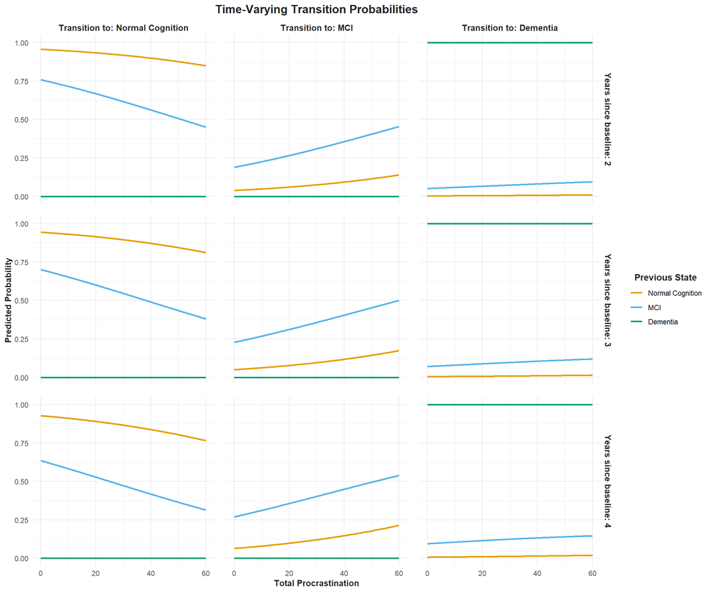

Figure 5: Predicted transition probabilities from the non-stationary model.

```r
expand.grid(
  Gender = factor(0),
  status_prev = levels(data_stack$status_prev),
  Total_p = seq(0, 60, length = 200),
  wave = unique(data_stack$wave)) |>
  modelr::add_predictions(model = fit_4, var = "pred", type = "probs") |>
  tidy_predictions() |>
  mutate(wave = factor(wave)) |>
  ggplot(aes(x = Total_p, y = prob, color = status_prev)) +
  geom_line(linewidth = 1) +
  ggokabeito::scale_color_okabe_ito() +
  labs(
    title = "Time-Varying Transition Probabilities",
    x = "Total Procrastination",
    y = "Predicted Probability", color = "Previous State") +
  facet_grid(wave ~ status, labeller = labeller(
    wave = function(x) paste("Years since baseline:", x),
    status = function(x) paste("Transition to:", x)
  )) +
  theme(panel.spacing = unit(1, "lines"))
```

#### 4.3.4 Estimated transition matrices

Let’s visualize the estimated time-varying transition matrices Figure 6

**Check out my code**

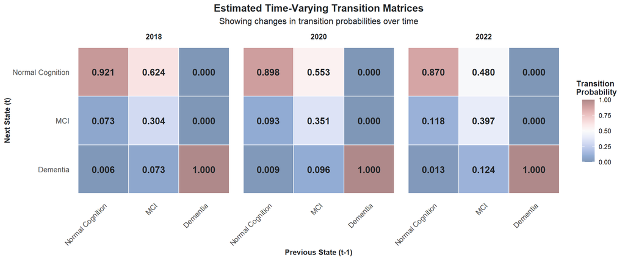

Figure 6: Estimated time-varying transition matrices.

```r
# Create prediction grid for each time point
time_points <- unique(data_stack$wave)
state_names <- c("Normal Cognition", "MCI", "Dementia")

# Get matrices for all time points
time_varying_matrices <- purrr::map(
  setNames(time_points, paste(time_points, "Years")),
  ~ get_time_varying_matrix(fit_4, .x)
)

# Converting into a tidy data frame
non_stationary_matrices <- purrr::imap_dfr(
  time_varying_matrices,
  ~ as.data.frame(.x) |>
    tibble::rownames_to_column("From") |>
    pivot_longer(-From, names_to = "To", values_to = "probability") |>
    mutate(Time = .y),
  .id = "Time_point"
) |>
  mutate(
    From = factor(From, levels = state_names),
    To = factor(To, levels = rev(state_names)),
    Time_point = forcats::fct_inorder(Time_point)
  )

# Plotting
non_stationary_matrices |>
ggplot(aes(x = From, y = To, fill = probability)) +
  geom_tile(color = "white", linewidth = 0.5) +
  geom_text(
    aes(label = format(round(probability, 3), nsmall = 3)),
    size = 4.5,
    color = "#212427",
    fontface = "bold") +
    colorspace::scale_fill_continuous_diverging(
    palette = "Blue-Red 3", mid = 0.50, alpha = 0.5,
    limits = c(0, 1), name = "Transition \nProbability") +
  labs(
    title = "Estimated Time-Varying Transition Matrices",
    subtitle = "Showing changes in transition probabilities over time",
    x = "Previous State (t-1)",
    y = "Next State (t)",
    fill = "Probability"
  ) +
  facet_wrap(~ Time_point, ncol = 3, labeller = labeller(
    Time_point = function(x){
      case_when(x == "2 Years" ~ "2018",
                x == "3 Years" ~ "2020",
                x == "4 Years" ~ "2022")
    })) +
  theme(
    axis.text = element_text(size = 10),
    axis.text.x = element_text(angle = 45, hjust = 1, vjust = 1),
    legend.position = "right",
    legend.text = element_text(size = 9),
    panel.grid = element_blank()
  )
```

## 5 Matrix distance metrics

Given two matrices $P = (p_{ij})$ and $\hat{P} = (\hat{p}_{ij})$ of size $m \times n$, we define the following distance measures

**Frobenius Norm (Matrix Euclidean Distance)**

$$D_{\text{Frobenius}}(P, \hat{P}) = \|P - \hat{P}\|_F = \sqrt{\sum_{i=1}^{m}\sum_{j=1}^{n} |p_{ij} - \hat{p}_{ij}|^2}$$

- Measures the Euclidean distance in matrix space
- Sensitive to large differences due to squaring
- Equivalent to the vector 2-norm of the flattened matrix

**Manhattan Distance (L1 Norm)**

$$D_{\text{Manhattan}}(P, \hat{P}) = \sum_{i=1}^{m}\sum_{j=1}^{n} |p_{ij} - \hat{p}_{ij}|$$

- Sum of absolute differences between corresponding elements
- Less sensitive to outliers than Frobenius norm
- Useful when sparse differences are important

**Maximum Difference (Infinity Norm)**

$$D_{\text{Max}}(A, B) = \max_{\substack{1 \leq i \leq m \\ 1 \leq j \leq n}} |a_{ij} - b_{ij}|$$

- Captures the single largest difference between elements
- Useful for worst-case analysis
- Ignores the distribution of other differences

**Mean Absolute Difference**

$$D_{\text{MeanAbs}}(P, \hat{P}) = \frac{1}{mn}\sum_{i=1}^{m}\sum_{j=1}^{n} |p_{ij} - \hat{p}_{ij}|$$

- Average absolute difference across all elements
- Scales with matrix size (unlike Manhattan distance)
- Easy to interpret as average error per element

**Root Mean Square Error (RMSE)**

$$D_{\text{RMSE}}(P, \hat{P}) = \sqrt{\frac{1}{mn}\sum_{i=1}^{m}\sum_{j=1}^{n} (p_{ij} - \hat{p}_{ij})^2}$$

- Similar to Frobenius but normalized by matrix size
- Sensitive to large errors due to squaring
- Common in statistical and machine learning applications

**Correlation-Based Distance**

$$D_{\text{Corr}}(P, \hat{P}) = 1 - \frac{\sum_{i=1}^{m}\sum_{j=1}^{n} (p_{ij} - \bar{P})(\hat{p}_{ij} - \bar{\hat{P}})}{\sqrt{\sum_{i=1}^{m}\sum_{j=1}^{n} (p_{ij} - \bar{P})^2 \sum_{i=1}^{m}\sum_{j=1}^{n} (\hat{p}_{ij} - \bar{\hat{p}})^2}}$$

- Measures linear relationship between matrix elements
- $\bar{P} = \frac{1}{mn}\sum_{i,j}p_{ij}$ (mean of all elements in $P$)
- $\bar{\hat{P}} = \frac{1}{mn}\sum_{i,j}\hat{p}_{ij}$ (mean of all elements in $\hat{P}$)
- Range: [0,2] where 0 = perfect positive correlation

**Kullback-Leibler Divergence**

For matrices where each row sums to 1 ($\sum_j p_{ij} = \sum_j \hat{P}_{ij} = 1$) and $p_{ij}, \hat{p}_{ij} > 0$:

$$D_{\text{KL}}(P \parallel \hat{P}) = \sum_{i=1}^{m}\sum_{j=1}^{n} p_{ij} \log\left(\frac{p_{ij}}{\hat{p}_{ij}}\right)$$

- Measures information loss when $\hat{P}$ approximates $P$
- Asymmetric: $D_{\text{KL}}(P \parallel \hat{P}) \neq D_{\text{KL}}(\hat{P} \parallel P)$
- $0\log0 = 0$ by convention
- In practice, add $\epsilon > 0$ (e.g., $10^{-10}$) to avoid zeros

### 5.1 Implementation

Let’s calculate the distance metrics between the observed $P$ and estimated transition matrices $\hat{P}$.

```r
p       <- transition_matrix_observed
p_hat   <- transition_matrix_estimated
epsilon <- 1e-10

# Creating tibble of distance metrics
distances <- tibble(
  Metric = c("Frobenius", "Manhattan", "Max", "MeanAbs", "RMSE", "Correlation", "KL"),
  Value = c(
    norm(p - p_hat, type = "F"),
    sum(abs(p - p_hat)),
    max(abs(p - p_hat)),
    mean(abs(p - p_hat)),
    sqrt(mean((p - p_hat)^2)),
    1 - cor(c(p), c(p_hat)),
    sum((p + epsilon) * log((p + epsilon) / (p_hat + epsilon)))
  )) |>
  mutate(Value = round(Value, 4))

distances |>
  mutate(Metric = case_when(
    Metric == "Frobenius" ~ "Frobenius Distance",
    Metric == "Manhattan" ~ "Manhattan Distance",
    Metric == "Max" ~ "Max Difference",
    Metric == "MeanAbs" ~ "Mean Absolute Difference",
    Metric == "RMSE" ~ "Root Mean Square Error",
    Metric == "Correlation" ~ "Correlation Distance",
    Metric == "KL" ~ "Kullback-Leibler Divergence"
  )) |>
  knitr::kable(caption = "Distance based metrics", align = "c") |>
  kableExtra::kable_styling(
    bootstrap_options = c("striped", "hover"),
    full_width = FALSE)
```

Distance based metrics

| Metric | Value |
| --- | --- |
| Frobenius Distance | 0.0396 |
| Manhattan Distance | 0.0608 |
| Max Difference | 0.0292 |
| Mean Absolute Difference | 0.0068 |
| Root Mean Square Error | 0.0132 |
| Correlation Distance | 0.0006 |
| Kullback-Leibler Divergence | 0.0019 |

### 5.2 Visualisation

Let’s visualize the distance metrics between the observed and estimated transition matrices (Figure 7).

**Check out my code**

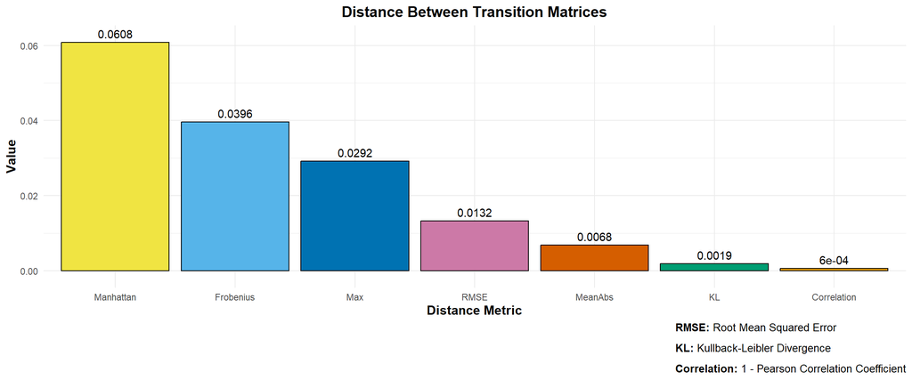

Figure 7: Distance metrics between observed and estimated transition matrices.

```r
caption = stringr::str_glue(
  "**RMSE:** Root Mean Squared Error\n
   **KL:** Kullback-Leibler Divergence\n
   **Correlation:** 1 - Pearson Correlation Coefficient")

distances |>
  ggplot(aes(x = reorder(Metric, -Value), y = Value, fill = Metric)) +
  geom_col(colour = "black") +
  geom_text(aes(label = Value), vjust = -0.5) +
  ggokabeito::scale_fill_okabe_ito() +
  scale_y_continuous(expand = expansion(mult = c(0.075, 0.075))) +
  labs(
    title = "Distance Between Transition Matrices",
    x = "Distance Metric",
    y = "Value",
    caption = caption) +
  theme_minimal() +
  theme(
    plot.title = element_text(hjust = 0.5, size = 14, face = "bold"),
    axis.title = element_text(face = "bold", size = 12),
    plot.caption = ggtext::element_markdown(size = 10),
    legend.position = "none")
```